# Snow Data Assignment: Web Scraping, Functions, and Iteration

Sam Leuthold

2-7-2022

# Assignment:

1. Extract the meteorological data URLs. Here we want you to use the `rvest` package to get the URLs for the `SASP forcing` and `SBSP_forcing` meteorological datasets.

```r
site_url <- 'https://snowstudies.org/archived-data/'

webpage <- read_html(site_url)

links <- webpage %>%
           html_nodes('a') %>%
           .[grepl('forcing',.)] %>%
           html_attr('href')
```

2. Download the meteorological data. Use the `download_file` and `str_split_fixed` commands to download the data and save it in your data folder. You can use a for loop or a map function.

```r
labels <- links %>%
            str_split_fixed("/", n = 8)

dataset <- labels[,8]

file.names <- paste0('data/',dataset)

map2(links[1:2],
     file.names[1:2],
     download.file)
```

3. Write a custom function to read in the data and append a site column to the data.

```r
headers <- pdf_text('https://snowstudies.org/wp-content/uploads/2022/02/Serially-Complete-Metadata-text08.pdf') %>%
            readr::read_lines(.) %>%
            trimws(.) %>%
            str_split_fixed(.,'\\.',2) %>%
            .[,2] %>%
            .[1:26] %>%
            str_trim(side = "left")

## I'd be interested to see the better Tidy version of this function. I messed with it for a while, but this ended up being the easiest way for me.

Meteorological_Data_Download <- function(site.name){

                                  file.index <- which(grepl(site.name, file.names) == T)

                                  file.path <- file.names[file.index]

                                  output <- read_fwf(file.path,
                                                     col_positions = fwf_empty(file.path),
                                                     show_col_types = F)

                                  colnames(output) <- headers

                                  output <- output[,1:14]

                                  output <- output %>%
                                              mutate(Site = site.name, .before = year)

                                  assign(paste0(site.name, ".data2"), output, envir = parent.frame())
}
```

4. Use the `map` function to read in both meteorological files. Display a summary of your tibble.

```r
sites <- c("SASP", "SBSP")

climate.data <- map_dfr(.x = sites[1:2],
                        .f = Meteorological_Data_Download)


knitr::kable(summary(climate.data))
```

|  | Site | year | month | day | hour | minute | second | precip [kg m-2 s-1] | sw down [W m-2] | lw down [W m-2] | air temp [K] | windspeed [m s-1] | relative humidity [%] | pressure [Pa] | specific humidity [g g-1] |
| --- | --- | --- | --- | --- | --- | --- | --- | --- | --- | --- | --- | --- | --- | --- | --- |
|  | Length:138336 | Min. :2003 | Min. : 1.000 | Min. : 1.00 | Min. : 0.00 | Min. :0 | Min. :0 | Min. :0.000e+00 | Min. :-9999.000 | Min. :-9999.0 | Min. :242.1 | Min. :-9999.000 | Length:138336 | Min. :63931 | Min. :1.650e-07 |
|  | Class :character | 1st Qu.:2005 | 1st Qu.: 3.000 | 1st Qu.: 8.00 | 1st Qu.: 5.75 | 1st Qu.:0 | 1st Qu.:0 | 1st Qu.:0.000e+00 | 1st Qu.: -3.510 | 1st Qu.: 173.4 | 1st Qu.:265.8 | 1st Qu.: 0.852 | Class :character | 1st Qu.:63931 | 1st Qu.:1.908e-03 |
|  | Mode :character | Median :2007 | Median : 6.000 | Median :16.00 | Median :11.50 | Median :0 | Median :0 | Median :0.000e+00 | Median : -0.344 | Median : 231.4 | Median :272.6 | Median : 1.548 | Mode :character | Median :65397 | Median :3.006e-03 |
|  | NA | Mean :2007 | Mean : 6.472 | Mean :15.76 | Mean :11.50 | Mean :0 | Mean :0 | Mean :3.838e-05 | Mean :-1351.008 | Mean :-1325.7 | Mean :272.6 | Mean : -790.054 | NA | Mean :65397 | Mean :3.561e-03 |
|  | NA | 3rd Qu.:2009 | 3rd Qu.: 9.000 | 3rd Qu.:23.00 | 3rd Qu.:17.25 | 3rd Qu.:0 | 3rd Qu.:0 | 3rd Qu.:0.000e+00 | 3rd Qu.: 294.900 | 3rd Qu.: 272.2 | 3rd Qu.:279.7 | 3rd Qu.: 3.087 | NA | 3rd Qu.:66863 | 3rd Qu.:4.731e-03 |
|  | NA | Max. :2011 | Max. :12.000 | Max. :31.00 | Max. :23.00 | Max. :0 | Max. :0 | Max. :6.111e-03 | Max. : 1341.000 | Max. : 365.8 | Max. :295.8 | Max. : 317.300 | NA | Max. :66863 | Max. :1.478e-02 |

5. Make a line plot of mean temp by year by site (using the `air temp [K]` variable). Is there anything suspicious in the plot? Adjust your filtering if needed.

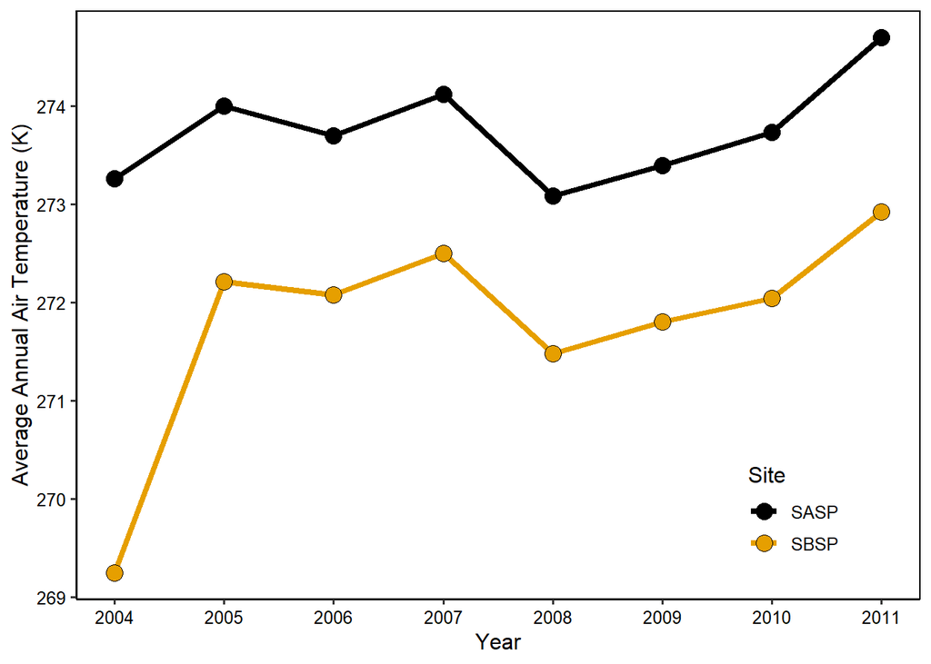

```r
mean.temp <- climate.data %>%
              filter(year != 2003) %>%
              group_by(Site, year) %>%
              summarise(Mean_Temp = mean(`air temp [K]`, na.rm = TRUE))


ggplot(data = mean.temp, aes(x = year, y = Mean_Temp)) +
  geom_line(aes(color = Site),
            size = 1.5) +
  geom_point(shape = 21,
             size = 4,
             aes(fill = Site)) +
  scale_fill_colorblind() +
  scale_color_colorblind() +
  scale_x_continuous(name = "Year",
                     breaks = seq(2003, 2011)) +
  ylab("Average Annual Air Temperature (K)") +
  theme_classic2() +
  theme(panel.border = element_rect(fill = NA),
        axis.text = element_text(color = "black"),
        legend.position = c(0.85,0.15))
```

6. Write a function that makes line plots of monthly average temperature at each site for a given year. Use a for loop to make these plots for 2005 to 2010. Are monthly average temperatures at the Senator Beck Study Plot ever warmer than the Snow Angel Study Plot? Hint: https://ggplot2.tidyverse.org/reference/print.ggplot.html

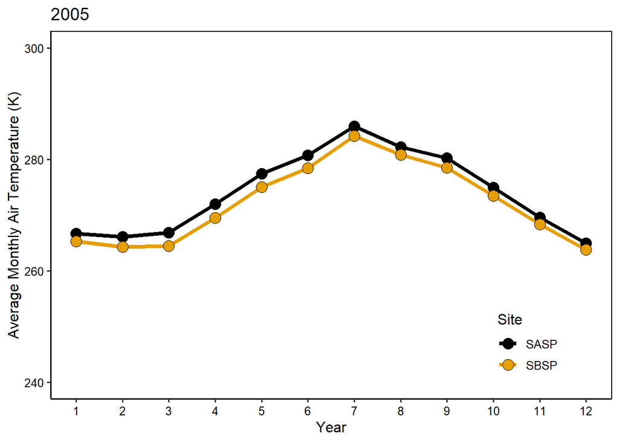

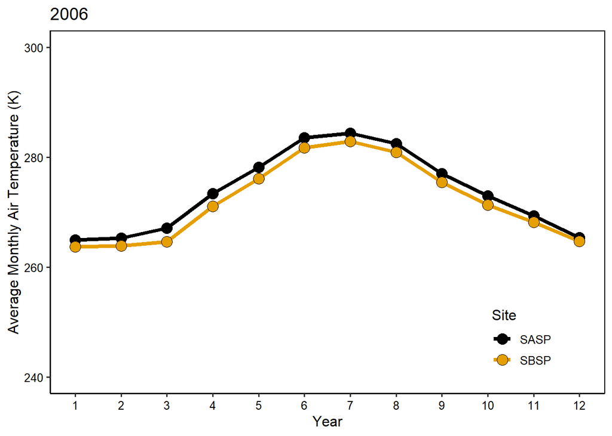

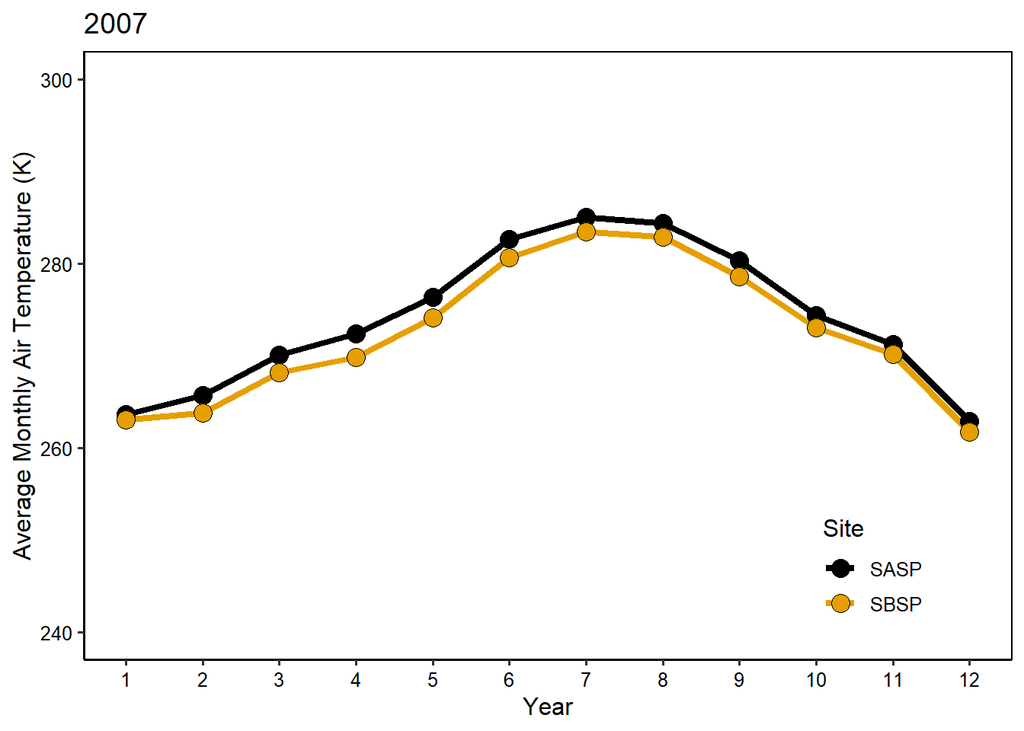

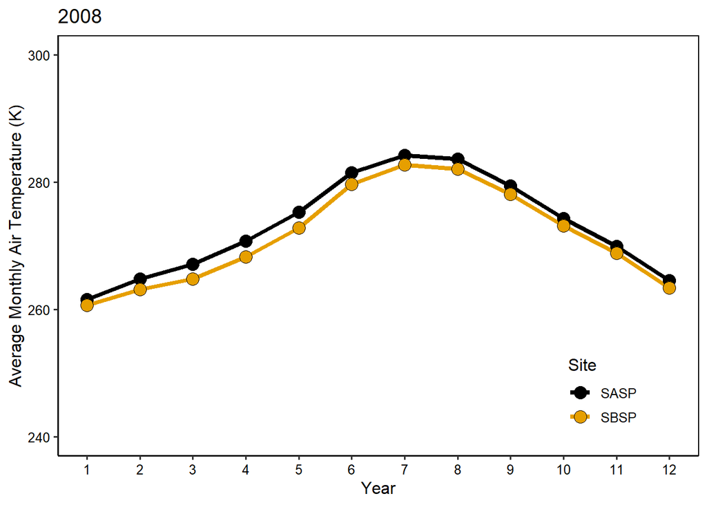

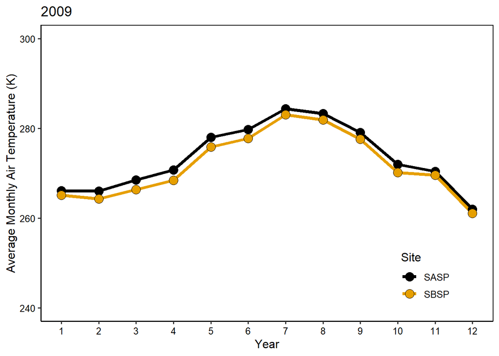

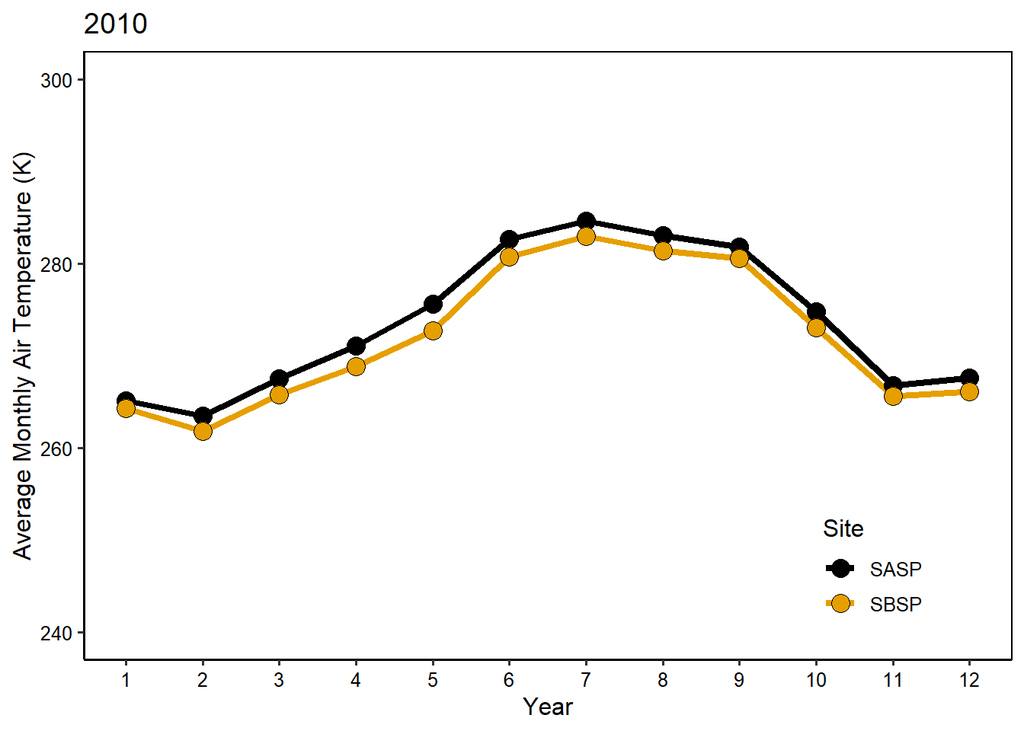

```r
Avg_Temp_Plotter <- function(Year){

  temp.temp.data <- climate.data %>%
    group_by(Site, year, month) %>%
    summarise(Monthly_Mean = mean(`air temp [K]`)) %>%
    filter(year == Year)


  temp.plot <- ggplot(data = temp.temp.data, aes(x = month, y = Monthly_Mean)) +
  geom_line(aes(color = Site),
            size = 1.5) +
  geom_point(shape = 21,
             size = 4,
             aes(fill = Site)) +
  scale_fill_colorblind() +
  scale_color_colorblind() +
  scale_x_continuous(name = "Year",
                     breaks = seq(1,12)) +
  scale_y_continuous(name = "Average Monthly Air Temperature (K)",
                    limits = c(240, 300)) +
    ggtitle(label = Year) +
  theme_classic2() +
  theme(panel.border = element_rect(fill = NA),
        axis.text = element_text(color = "black"),
        legend.position = c(0.85,0.15))

  print(temp.plot)

}

years <- seq(2005, 2010)

for (i in 1:length(years)){

  Avg_Temp_Plotter(years[i])

}
```

Bonus: Make a plot of average daily precipitation by day of year (averaged across all available years). Color each site.

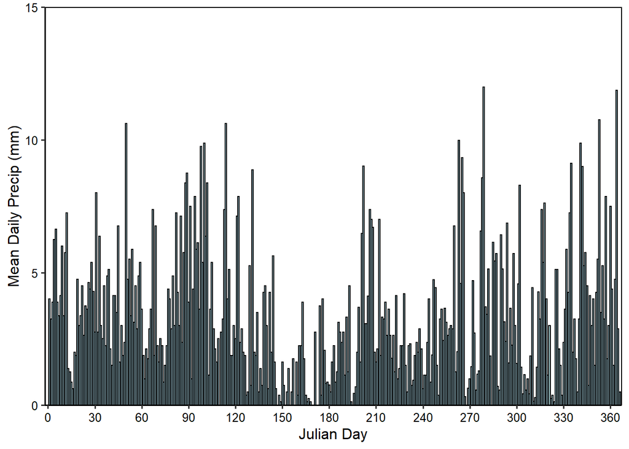

```r
daily.precipitation <-  climate.data %>%
                          mutate(Date = paste0(day,"/", month, "/", year)) %>%
                          mutate(Date = as.Date(Date, format = "%d/%m/%Y")) %>%
                          mutate(DOY = yday(Date)) %>%
                          mutate(Precip_mm = `precip [kg m-2 s-1]` * 86400) %>%
                          group_by(Site, DOY) %>%
                          summarize(Mean_Precip = mean(Precip_mm))

ggplot(daily.precipitation[daily.precipitation$Site == "SASP",], aes(x = DOY, y = Mean_Precip)) +
  geom_col(color = "black",
           fill = "lightblue") +
  scale_x_continuous(name = "Julian Day",
                     limits = c(-2, 367),
                     breaks = seq(0, 360, 30),
                     expand = c(0,0)) +
   scale_y_continuous(name = "Mean Daily Precip (mm)",
                     limits = c(0, 15),
                     expand = c(0,0)) +
  theme_classic2() +
  theme(panel.border = element_rect(fill = NA),
  axis.text = element_text(color = "black"),
  legend.position = c(0.85,0.15))
```

Bonus #2: Use a function and for loop to create yearly plots of precipitation by day of year. Color each site.

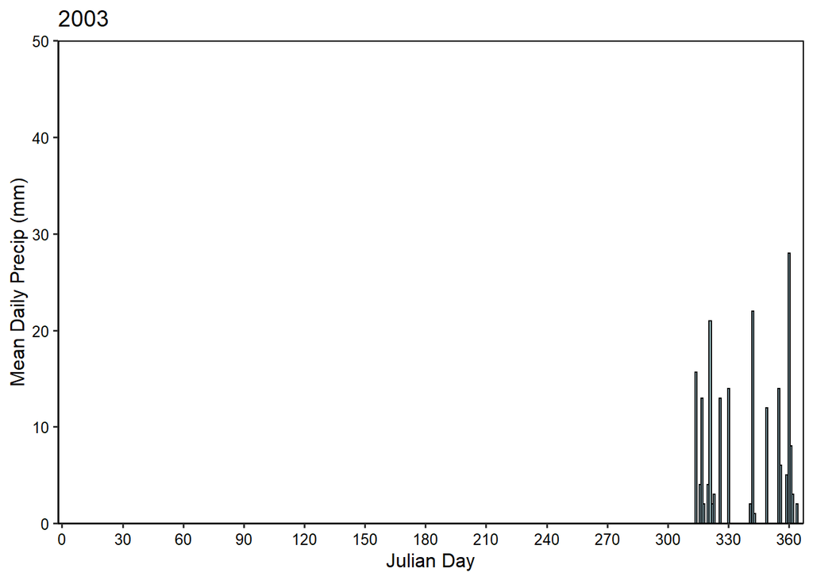

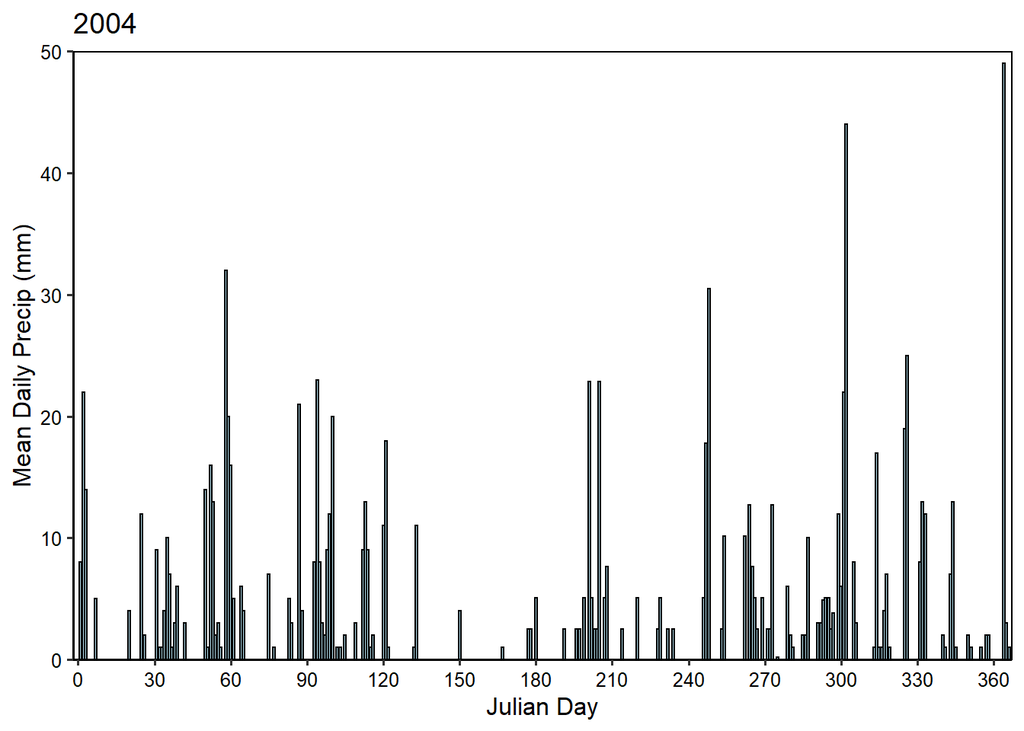

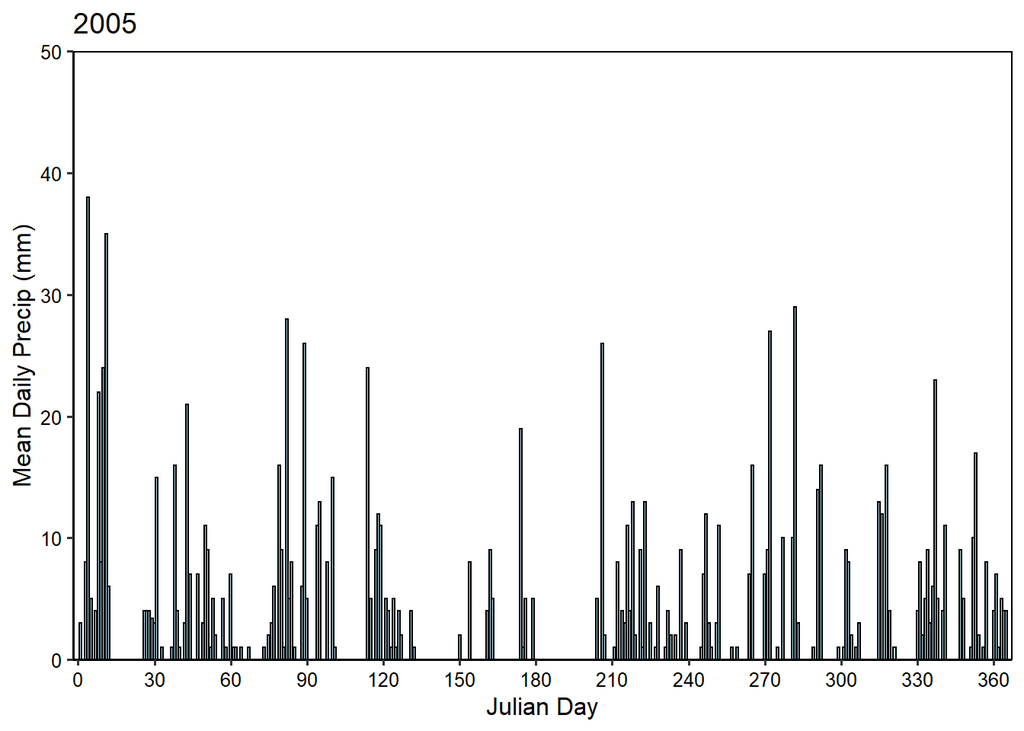

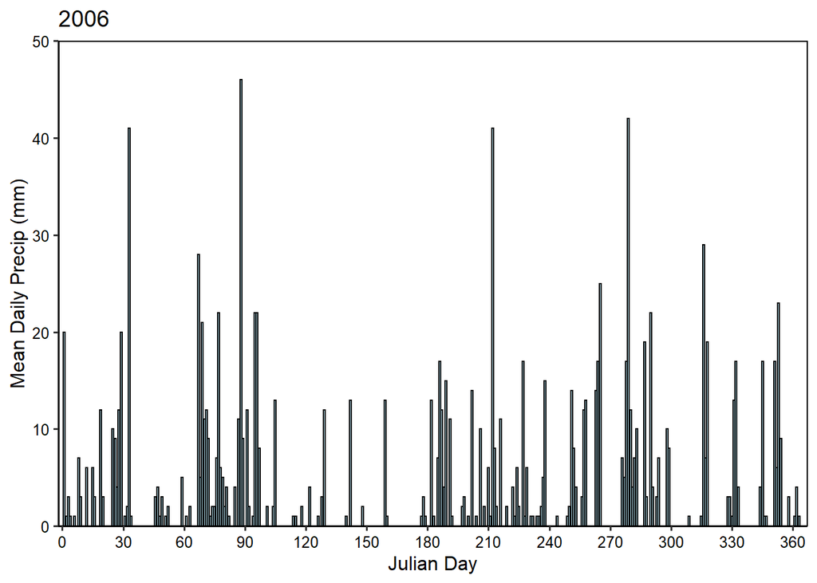

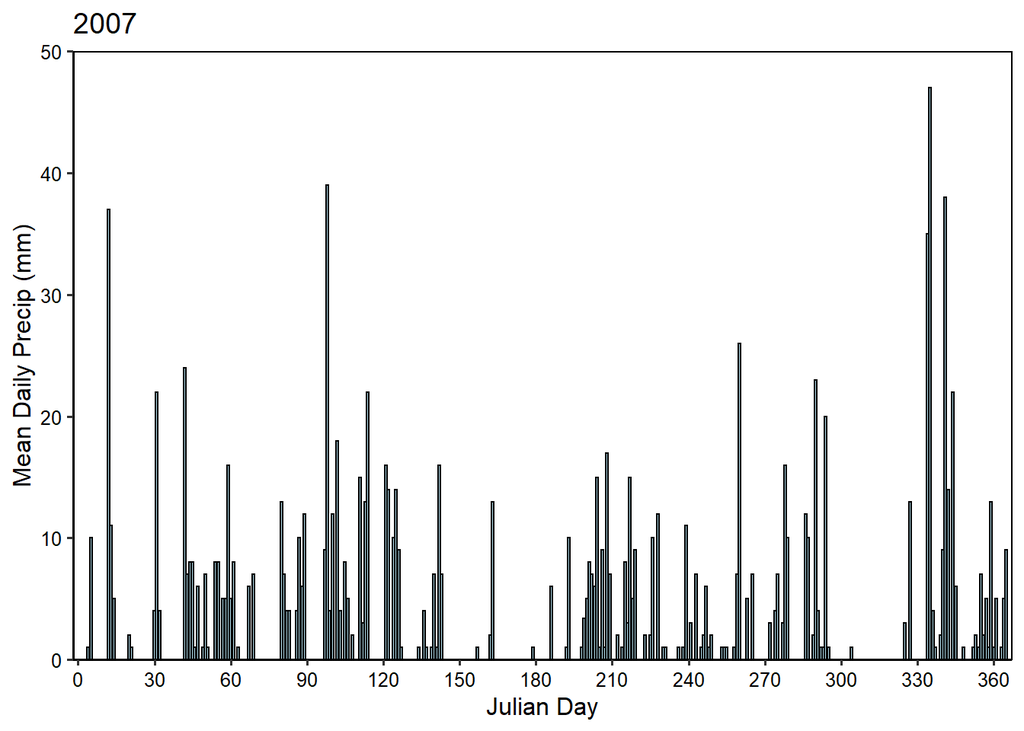

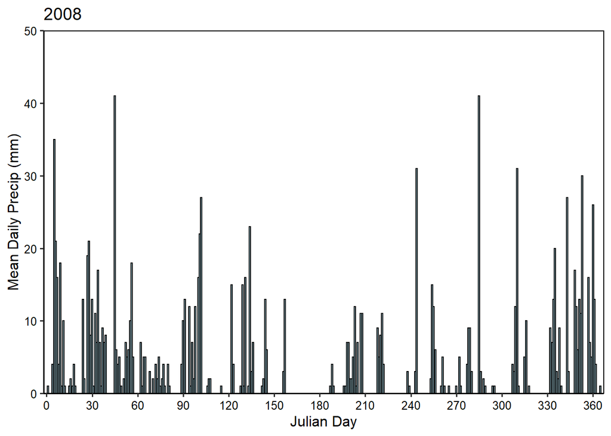

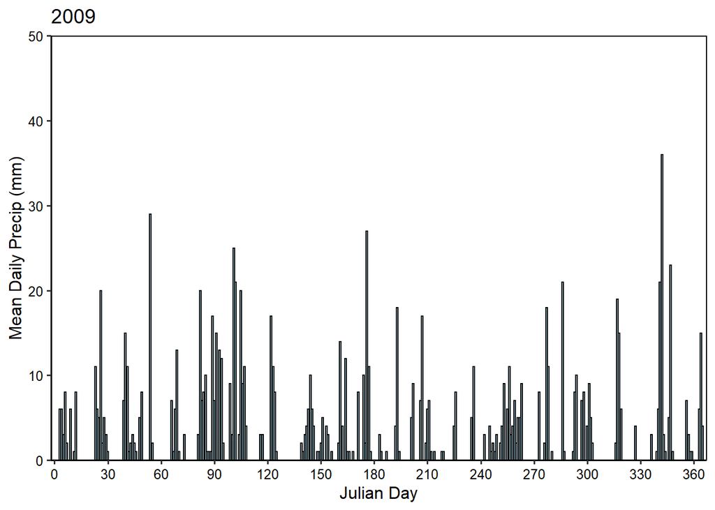

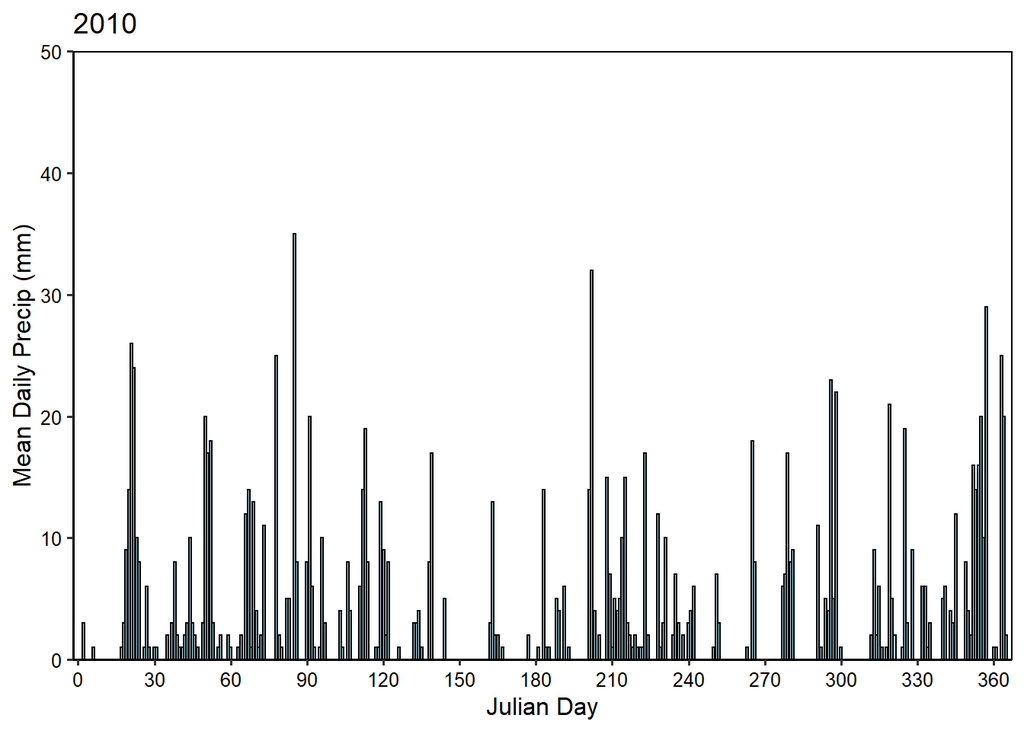

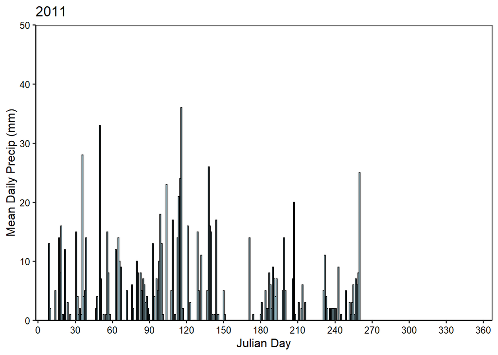

```r
Yearly_Precip <- function(input.year){

                  precip.out <- climate.data %>%
                                  filter(year == input.year) %>%
                                  filter(Site == "SASP") %>%
                                  mutate(Date = paste0(day,"/", month, "/", year)) %>%
                                  mutate(Date = as.Date(Date, format = "%d/%m/%Y")) %>%
                                  mutate(DOY = yday(Date)) %>%
                                  mutate(Precip_mm = `precip [kg m-2 s-1]` * 86400) %>%
                                  group_by(DOY) %>%
                                  summarize(Mean_Precip = mean(Precip_mm))

}


for(i in 1:length(unique(climate.data$year))){

  annual.precip <- Yearly_Precip(unique(climate.data$year)[i])

  plot <- ggplot(data = annual.precip, aes(x = DOY, y = Mean_Precip)) +
           geom_col(color = "black",
                    fill = "lightblue") +
           scale_x_continuous(name = "Julian Day",
                              limits = c(-2, 367),
                              breaks = seq(0, 360, 30),
                              expand = c(0,0)) +
          scale_y_continuous(name = "Mean Daily Precip (mm)",
                             limits = c(0, 50),
                             expand = c(0,0)) +
           ggtitle(label = unique(climate.data$year)[i]) +
           theme_classic2() +
           theme(panel.border = element_rect(fill = NA),
                 axis.text = element_text(color = "black"),
                 legend.position = c(0.85,0.15))

  print(plot)

}
```